# Report INBIOS BBB WGS

Dhihram Tenrisau

2026-06-29

## Background

Avian Influenza (A H5N1) became one of the public health concern. This virus first emerged in 1996 and have been causing outbreaks in wild birds and poultry.[^1] As of 1 March 2026, nine additional human cases of A(H5N1) virus infections from Bangladesh and Cambodia. The majority of reported human infections have been associated with exposure to infected animals in poultry and wildlife. [^2]

This study aims to perform a comprehensive genomic analysis of a human A(H5N1) case by mapping its sequences to the reference strain GCF_000864105.1 (A/goose/Guangdong/1/1996(H5N1)).[^3] By identifying and annotating viral variants, we intend to characterize the genetic divergence of this isolate and identify key mutations in mammalian, potential adaptation, and potential changes in viral fitness.

## Method

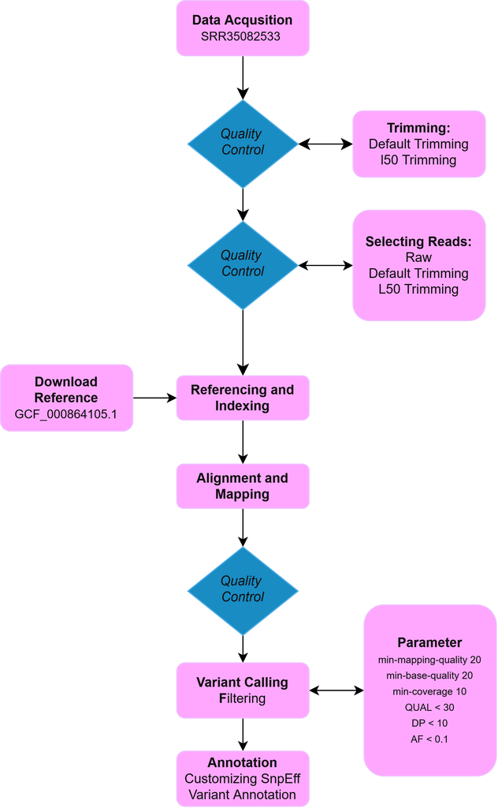

### Data Acqusition

Whole-genome sequencing (WGS) data were downloaded from the NCBI Sequence Read Archive (SRA) under accession SRR35082533 using the SRA Toolkit (`prefetch` and `fasterq-dump`). The downloaded `.sra` file was converted into paired-end FASTQ files, consisting of forward (R1) and reverse (R2) reads.

### Initial Quality Control

The downloaded WGS data undergoes quality control using fastqc, followed by an aggregated quality control assessment using `multiqc`.

### Read Trimming

The data is then trimmed to clean the reads from adapters and low-quality bases. Trimming is performed twice using stricter parameters (excluding reads with a length of less than 50).

### Post-Trimming Quality Control

The trimmed sequences are evaluated again using `fastqc` and `multiqc`. The best trimming results will be used for the subsequent steps in the pipeline.

### Download Reference and Indexing

The reference genome is retrieved from NCBI using the RefSeq ID: GCF_000864105.1 and is then renamed to `reference.fna` for indexing.

### Alignment / Mapping

The cleaned reads from the trimming step are mapped and aligned to the `reference.fna` file. SAM to BAM Conversion, Sorting, and Indexing

The alignment results, initially in SAM format, are converted into BAM format. Next, the file is sorted and indexed to create a `.bai` file, allowing the BAM file to be read quickly by downstream tools.

### Alignment Quality Control

Next, an assessment is performed to check the percentage of mapped reads and the read coverage for each segment/reference.

### Variant Calling

Variant calling is performed to identify differences between the sample and the reference genome. This outputs a `variants_raw.vcf` file using the following parameters:

- `min-mapping-quality 20`: Includes only reads with sufficiently good mapping quality
- `min-base-quality 20`: Includes only bases with sufficiently good quality
- `min-coverage 10`: Variants are only called if the coverage is at least 10x

Subsequently, variant filtering is performed to remove variants based on the following parameters:

- `QUAL < 30`: Filters out low-quality variants
- `DP < 10`: Filters out low depth/coverage
- `AF < 0.1`: Filters out allele frequencies of < 10%

**Customizing SnpEff Database:**

The `.gbff` data file is downloaded for the NCBI reference GCF_000864105.1. The database is then customized for H5N1 by copying the `.fna` and `.gbff` files into the H5N1 directory within the SnpEff configuration.

### Annotate Variants

SnpEff is used to perform variant annotation to identify: synonymous variants, missense variants, stop-gained mutations, mutation positions within the gene, amino acid changes, and affected genes.

## Results

### QC Pre-Post Trimming

Table 1. Summary of sequencing quality before and after trimming I

| Parameter | RawR1R2 | CleanR1R2 | Cleanl50R1R2 |
| --- | --- | --- | --- |
| Total reads | 44,821,894 | 44,821,880 | 44,816,946 |
| Total read pairs | 22,410,947 | 22,410,940 | 22,408,473 |
| Total bases | 6,723,284,100 | ~6,723,282,000* | ~6,722,541,900* |
| GC content (%) | 50 | 50 | 50 |
| Q30 (%) | Not available | 91.00% | 91.00% |
| % reads passed trimming | 100% | ~100% | 99.99% |
| % reads removed | 0% | 0.00% | 0.01% |

Table 2. Summary of sequencing quality before and after trimming II

| Read | Read name | Total sequences | Retention vs raw | Read length | GC | Per base quality | Adapter content | Per base content | Length Distribution | Duplication |
| --- | --- | --- | --- | --- | --- | --- | --- | --- | --- | --- |
| R1 | Raw | 22,410,947 | 100% | 150 | 50 | PASS | PASS | FAIL | PASS | FAIL |
| R1 | Clean | 22,410,940 | ~100% | 18–150 | 50 | PASS | PASS | FAIL | FAIL | FAIL |
| R1 | Clean l50 | 22,408,473 | 99.99% | 50–150 | 50 | PASS | PASS | FAIL | FAIL | FAIL |
| R2 | Raw | 22,410,947 | 100% | 150 | 50 | PASS | PASS | WARNING | PASS | FAIL |
| R2 | Clean | 22,410,940 | ~100% | 31–150 | 50 | PASS | PASS | WARNING | FAIL | FAIL |
| R2 | Clean l50 | 22,408,473 | 99.99% | 50–150 | 50 | PASS | PASS | WARNING | FAIL | FAIL |

The quality assessment indicated that no adapter contamination was detected in the raw sequencing data; therefore, trimming did not result in a significant improvement in read quality. Based on the `fastp` report, the raw reads had already undergone adapter trimming, and the `FastQC` results showed that the read length and overall sequence quality were retained. Consequently, the raw sequencing data were used for the subsequent alignment and variant analysis.

### Aligmnment

Table 3. Alignment Summary

| Metric | Value | Percentage |
| --- | --- | --- |
| Total reads | 44,823,172 | 100% |
| Primary reads | 44,821,894 | 100.00% |
| Supplementary alignments | 1,278 | 0.00% |
| Mapped reads | 245,815 | 0.55% |
| Primary mapped reads | 244,537 | 0.55% |
| Paired-end reads | 44,821,894 | 100% |
| Properly paired | 242,094 | 0.54% |
| Singleton reads | 1,875 | 0.00% |

Table 4. Genome coverage and depth per genes

| Segment | Gene | Length..bp. | Reads.mapped | Genome.coverage…. | Mean.depth…. | Mean.MAPQ |
| --- | --- | --- | --- | --- | --- | --- |
| NC_007357.1 | PB2 | 2,341 | 8,990 | 98.80 | 566.8 | 59.9 |
| NC_007358.1 | PB1 | 2,341 | 19,762 | 99.23 | 1,230.90 | 59.9 |
| NC_007359.1 | PA | 2,233 | 7,035 | 99.33 | 463.1 | 59.9 |
| NC_007362.1 | HA | 1,760 | 43,678 | 99.66 | 3,676.00 | 60.0 |
| NC_007360.1 | NP | 1,565 | 93,260 | 99.11 | 8,759.10 | 59.9 |
| NC_007361.1 | NA | 1,458 | 3,830 | 93.69 | 369.1 | 59.7 |
| NC_007363.1 | M | 1,027 | 57,378 | 98.83 | 8,184.20 | 60.0 |
| NC_007364.1 | NS | 865 | 11,882 | 39.54 | 1,194.90 | 54.5 |

A total of 44.8 million paired-end reads were generated, with 245,815 reads (0.55%) successfully mapped to the influenza A (H5N1) reference genome. Despite the low mapping rate, seven genome segments showed >93% coverage with high mean sequencing depths ranging from 369× to 8,759× and excellent mapping quality (mean MAPQ = 60). The HA segment had the highest genome coverage (99.66%), while the NS segment showed the lowest genome coverage (39.54%).

### Variant Analysis

Table 5. Summary of variant detection

| Metric | Value |
| --- | --- |
| Total variants detected | 562 |
| SNP | 438 (77.9%) |
| MNP | 124 (22.1%) |
| Insertions | 0 |
| Deletions | 0 |
| Variant density | 1 variant / 24 bp |

Table 6. Variant Distribution per Genes

[output not shown]

Table 7. Variant impact distribution

| Impact | Count | Percentage |
| --- | --- | --- |
| LOW | 501 | 52.30% |
| MODERATE | 167 | 17.43% |
| MODIFIER | 290 | 30.27% |

Functional annotation performed using SnpEff revealed that the majority of variant effects were classified as having a LOW (52.30%) or MODIFIER (30.27%) impact. Variants categorized as having a MODERATE impact which predominantly include missense mutations capable of altering the protein structure—accounted for 17.43% (n=167) of the total annotated effects (Table 7).

Table 8. SnpEff Variant Annotation and Functional Impact Assessment of HA

| Gene | Pos | Ref | Alt | Effect | Impact | ProteinChange |
| --- | --- | --- | --- | --- | --- | --- |
| HA | 1607 | C | T | missense_variant | MODERATE | p.Thr529Ile |
| HA | 1602 | G | A | missense_variant | MODERATE | p.Met527Ile |
| HA | 1566 | C | A | missense_variant | MODERATE | p.Asn515Lys |
| HA | 1517 | A | G | missense_variant | MODERATE | p.Lys499Arg |
| HA | 1306 | C | A | missense_variant | MODERATE | p.Gln429Lys |
| HA | 1028 | C | G | missense_variant | MODERATE | p.Thr336Ser |
| HA | 856 | G | A | missense_variant | MODERATE | p.Ala279Thr |
| HA | 718 | C | T | missense_variant | MODERATE | p.Pro233Ser |
| HA | 699 | TCCAGA | ACCAAG | missense_variant | MODERATE | p.Glu228Arg |
| HA | 634 | A | G | missense_variant | MODERATE | p.Lys205Glu |
| HA | 535 | G | A | missense_variant | MODERATE | p.Ala172Thr |
| HA | 483 | TGGGAG | GGGAAA | missense_variant | MODERATE | p.HisGlyArg154GlnGlyLys |
| HA | 455 | CA | TG | missense_variant | MODERATE | p.Ser145Leu |
| HA | 447 | T | A | missense_variant | MODERATE | p.Asp142Glu |
| HA | 440 | A | G | missense_variant | MODERATE | p.Asn140Ser |
| HA | 392 | C | T | missense_variant | MODERATE | p.Thr124Ile |
| HA | 326 | C | T | missense_variant | MODERATE | p.Ala102Val |
| HA | 320 | G | A | missense_variant | MODERATE | p.Ser100Asn |
| HA | 202 | A | G | missense_variant | MODERATE | p.Asn61Asp |
| HA | 43 | C | T | missense_variant | MODERATE | p.Leu8Phe |

Table 9. SnpEff Variant Annotation and Functional Impact Assessment of PB2

| Gene | Pos | Ref | Alt | Effect | Impact | ProteinChange |
| --- | --- | --- | --- | --- | --- | --- |
| PB2 | 2249 | T | C | missense_variant | MODERATE | p.Phe741Ser |
| PB2 | 2206 | AT | GG | missense_variant | MODERATE | p.Met727Gly |
| PB2 | 2123 | GA | AG | missense_variant | MODERATE | p.Arg699Lys |
| PB2 | 1906 | GAGCC | AAGCA | missense_variant | MODERATE | p.GluPro627LysGln |
| PB2 | 1795 | AGC | GGT | missense_variant | MODERATE | p.Ser590Gly |
| PB2 | 1762 | T | C | missense_variant | MODERATE | p.Ser579Pro |
| PB2 | 1550 | A | G | missense_variant | MODERATE | p.Gln508Arg |
| PB2 | 1434 | AAGCG | CAGCA | missense_variant | MODERATE | p.Ala471Thr |
| PB2 | 1091 | A | G | missense_variant | MODERATE | p.Lys355Arg |
| PB2 | 1028 | ATGGA | GTGGG | missense_variant | MODERATE | p.Asn334Ser |
| PB2 | 349 | A | G | missense_variant | MODERATE | p.Thr108Ala |
| PB2 | 340 | ACA | GCG | missense_variant | MODERATE | p.Thr105Ala |
| PB2 | 219 | G | A | missense_variant | MODERATE | p.Met64Ile |

## Discussion

A tiny fraction (0.55%) of our massive sequencing data mapped to the SRR35082533 as the human case of H5N1. The only major anomaly was the NS gene, where we only recovered about 40% of the sequence. This suggests several points: it suggests the virus has either deleted a portion of this gene or mutated it so heavily that our mapping tools couldn’t recognize it, which can directly affect how the virus fights off the host’s immune system.

Alongside this, a multiple mutation (H154Q and R156K) altered a critical region. This indicated the virus physically might replicate and has adapt in this human case. [^7]

Alarmingly, I identified the famous E627K mutation in the PB2 gene. This specific PB2 mutation acts as an engine upgrade allowing the virus transmission among mammals or humans, also spillover from birds.[^8] In fact this mutation also reported from cow cases, underscoring its role in expansion of host tropism.[^9]

The low mapping rate of 0.55% in your H5N1 analysis is a significant limitation of this study. This might be happened the different host between reference (goose) and sequence (human/homo sapiens).

## Supplement Materials

Code and summary of output files can be accessed on https://github.com/Dhihram/INBIO_BBB_WGS

[^1]: WHO, https://www.who.int/teams/global-influenza-programme/avian-influenza/avian-a-h5n1-virus
[^2]: https://cdn.who.int/media/docs/default-source/influenza/human-animal-interface-risk-assessments/updated-joint-fao-who-woah-public-health-assessment-of-recent-high-pathogenicity-avian-influenza-a(h5)-virus-events-in-animals-and-people–18-may-2026.pdf?sfvrsn=d660ff84_1&download=true
[^3]: Xu X, Subbarao, Cox NJ, Guo Y. Genetic characterization of the pathogenic influenza A/Goose/Guangdong/1/96 (H5N1) virus: similarity of its hemagglutinin gene to those of H5N1 viruses from the 1997 outbreaks in Hong Kong. Virology. 1999 Aug 15;261(1):15-9. doi: 10.1006/viro.1999.9820. PMID: 10484749.
[^4]: Hailiang Sun, Zifeng Pang, Cuishan Mai, Hejie Wang, Yutan Yang, Junkun Fan, Peiting Zhong, Wenrui Yan, Ming Liao, Genetic evolution, phylodynamic and phylogeographic of H5Ny AIVs in mammals, Animals and Zoonoses, Volume 1, Issue 1, 2025, Pages 69-85, ISSN 2950-2489, https://doi.org/10.1016/j.azn.2024.10.001.
[^5]: Ayora-Talavera G, Shelton H, Scull MA, Ren J, Jones IM, Pickles RJ, Barclay WS. Mutations in H5N1 influenza virus hemagglutinin that confer binding to human tracheal airway epithelium. PLoS One. 2009 Nov 18;4(11):e7836. doi: 10.1371/journal.pone.0007836. PMID: 19924306; PMCID: PMC2775162.
[^6]: Suttie A, Deng YM, Greenhill AR, Dussart P, Horwood PF, Karlsson EA. Inventory of molecular markers affecting biological characteristics of avian influenza A viruses. Virus Genes. 2019 Dec;55(6):739-768. doi: 10.1007/s11262-019-01700-z. Epub 2019 Aug 19. PMID: 31428925; PMCID: PMC6831541.
[^7]: Association of poultry vaccination with the interspecies transmission and molecular evolution of H5 subtype avian influenza virus. Bingying Li, Jayna Raghwani, Sarah C. Hill, Sarah François, Noémie Lefrancq, Yilin Liang, Zengmiao Wang, Lu Dong, Phillipe Lemey, Oliver G. Pybus, Huaiyu Tian. bioRxiv 2023.12.20.572711; doi: https://doi.org/10.1101/2023.12.20.572711
[^8]: Marchenko, V.Y., Panova, A.S., Kolosova, N.P. *et al.* Characterization of H5N1 avian influenza virus isolated from bird in Russia with the E627K mutation in the PB2 protein. Sci Rep 14, 26490 (2024). https://doi.org/10.1038/s41598-024-78175-y
[^9]: Chakraborty C, Das A, Bhattacharya M, Islam MA. Emerging H5N1 mutations (PB2-D701N, PB2-E627K, HA-S110N, NA-V116X) in a recent outbreak in U.S. dairy cows: need for continuous monitoring. Ann Med Surg (Lond). 2025 Jul 16;87(8):5347-5350. doi: 10.1097/MS9.0000000000003538. PMID: 40787498; PMCID: PMC12333729.